# Dimensional Reduction - Start Here

# Introduction

It is typically a challenge to find the optimal method to reduce the dimensionality of mixed data. If all the data is numeric, then PCA is a clear and obvious choice. If all the data is categorical, then MCA would be a potential solution. What do you do when the data has both numeric and categorical data - like most data do?

There are difference approaches. The best solution is to use different models to identify the principle components and test these on the models that get created later. Let the model performance determine the optimal solution.

There are 3 methodologies that could be used:

1. PCA and Dummy Variables / One Hot Encoding - this is the most-used solution’s (but not necessarily the best one)
2. [Factor Analysis For Mixed Data](https://www.rdocumentation.org/packages/FactoMineR/versions/1.36/topics/FAMD)
3. [Principal component analysis of mixed data](https://cran.r-project.org/web/packages/PCAmixdata/PCAmixdata.pdf)

## Get Data

```r
#load train and test file
train <- read.csv("./data/train_Big.csv")
test <- read.csv("./data/test_Big.csv")

#add a column
test$Item_Outlet_Sales <- 1#so the rbind works

#combine the data set
combi <- rbind(train, test)

#impute missing values with median
combi$Item_Weight[is.na(combi$Item_Weight)] <- median(combi$Item_Weight, na.rm = TRUE)

#impute 0 with median
combi$Item_Visibility <- ifelse(combi$Item_Visibility == 0, median(combi$Item_Visibility), combi$Item_Visibility)

#find mode and impute
table(combi$Outlet_Size, combi$Outlet_Type)
```

```
##
##          Grocery Store Supermarket Type1 Supermarket Type2
##                    925              3091                 0
##   High               0              1553                 0
##   Medium             0              1550              1546
##   Small            880              3100                 0
##
##          Supermarket Type3
##                          0
##   High                   0
##   Medium              1559
##   Small                  0
```

```r
levels(combi$Outlet_Size)[1] <- "Other"

# Removing the dependent (response) variable and other identifier variables( if any). We are practicing an unsupervised learning technique, hence response variable must be removed.

#remove the dependent and identifier variables
my_data <- subset(combi, select = -c(Item_Outlet_Sales, Item_Identifier, Outlet_Identifier))
```

Each of these are demonstrated below.

# PCA and Dummy Variables / One Hot Encoding

## Quick Intro to PCA

A principal component is a normalized linear combination of the original predictors in a data set.

The **first principal component** is a linear combination of original predictor variables which captures the maximum variance in the data set. It determines the direction of highest variability in the data. Larger the variability captured in first component, larger the information captured by component. No other component can have variability higher than first principal component.

The first principal component results in a line which is closest to the data i.e. it minimizes the sum of squared distance between a data point and the line.

The **second principal component** is also a linear combination of original predictors which captures the remaining variance in the data set and is uncorrelated. In other words, the correlation between first and second component should is zero.

If the two components are uncorrelated, their directions should be orthogonal (image below). This image is based on a simulated data with 2 predictors. Notice the direction of the components, as expected they are orthogonal. This suggests the correlation b/w these components in zero.

All succeeding principal component follows a similar concept i.e. they capture the remaining variation without being correlated with the previous component.

The directions of these components are identified in an unsupervised way i.e. the response variable(Y) is not used to determine the component direction. Therefore, it is an unsupervised approach.

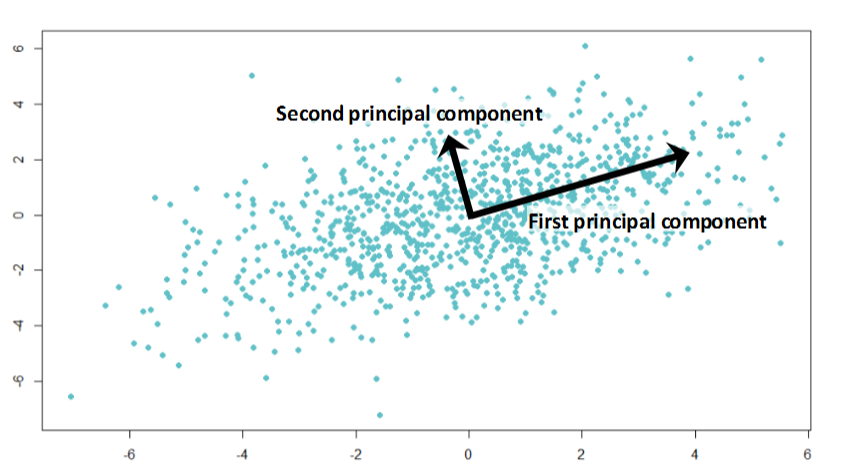

> Partial least square (PLS) is a supervised alternative to PCA. PLS assigns higher weight to variables which are strongly related to response variable to determine principal components.

## Preparing for PCA

Since PCA works on numeric variables, let’s see if we have any variable other than numeric.

```r
str(my_data)
```

```
## 'data.frame':    14204 obs. of  9 variables:
##  $ Item_Weight              : num  9.3 5.92 17.5 19.2 8.93 ...
##  $ Item_Fat_Content         : Factor w/ 5 levels "LF","low fat",..: 3 5 3 5 3 5 5 3 5 5 ...
##  $ Item_Visibility          : num  0.016 0.0193 0.0168 0.054 0.054 ...
##  $ Item_Type                : Factor w/ 16 levels "Baking Goods",..: 5 15 11 7 10 1 14 14 6 6 ...
##  $ Item_MRP                 : num  249.8 48.3 141.6 182.1 53.9 ...
##  $ Outlet_Establishment_Year: int  1999 2009 1999 1998 1987 2009 1987 1985 2002 2007 ...
##  $ Outlet_Size              : Factor w/ 4 levels "Other","High",..: 3 3 3 1 2 3 2 3 1 1 ...
##  $ Outlet_Location_Type     : Factor w/ 3 levels "Tier 1","Tier 2",..: 1 3 1 3 3 3 3 3 2 2 ...
##  $ Outlet_Type              : Factor w/ 4 levels "Grocery Store",..: 2 3 2 1 2 3 2 4 2 2 ...
```

6 out of 9 variables are categorical in nature. Convert these categorical variables into numeric using one hot encoding.

There are two methods presented: using the `dummies` package and the other using the `dummyVars` function from `caret`. I usually like to use `caret` whenever I can but in this case, `dummies` is much easier.

```r
new_my_data <- dummy.data.frame(my_data, names = c("Item_Fat_Content","Item_Type", "Outlet_Establishment_Year","Outlet_Size", "Outlet_Location_Type","Outlet_Type"))
```

Typically, dummyVars works great but in this example because one variable started as an int when it was really a factor, it created challenges that are best avoided.

```r
#typically you would enter: new_my_data2 <- dummyVars(~. , my_data) but that will not convert Outlet_Establishment_Year because it is an int
#Therefore, need to handle this
my_data2 <- my_data
my_data2$Outlet_Establishment_Year <- as.factor(my_data2$Outlet_Establishment_Year)
str(my_data2)
```

```
## 'data.frame':    14204 obs. of  9 variables:
##  $ Item_Weight              : num  9.3 5.92 17.5 19.2 8.93 ...
##  $ Item_Fat_Content         : Factor w/ 5 levels "LF","low fat",..: 3 5 3 5 3 5 5 3 5 5 ...
##  $ Item_Visibility          : num  0.016 0.0193 0.0168 0.054 0.054 ...
##  $ Item_Type                : Factor w/ 16 levels "Baking Goods",..: 5 15 11 7 10 1 14 14 6 6 ...
##  $ Item_MRP                 : num  249.8 48.3 141.6 182.1 53.9 ...
##  $ Outlet_Establishment_Year: Factor w/ 9 levels "1985","1987",..: 5 9 5 4 2 9 2 1 6 8 ...
##  $ Outlet_Size              : Factor w/ 4 levels "Other","High",..: 3 3 3 1 2 3 2 3 1 1 ...
##  $ Outlet_Location_Type     : Factor w/ 3 levels "Tier 1","Tier 2",..: 1 3 1 3 3 3 3 3 2 2 ...
##  $ Outlet_Type              : Factor w/ 4 levels "Grocery Store",..: 2 3 2 1 2 3 2 4 2 2 ...
```

```r
new_my_data2 <- dummyVars(~., my_data2)
new_my_data2 <- data.frame(predict(new_my_data2, my_data2))
```

Now have all the numerical values. Re-divide the data into test and train.

```r
pca.train <- new_my_data[1:nrow(train),]
pca.test <- new_my_data[-(1:nrow(train)),]
```

The base R `prcomp` is used to perform PCA. By default, it centers the variable to have mean equals to zero. With parameter scale. = T, we normalize the variables to have standard deviation equals to 1.

```r
prin_comp <- prcomp(pca.train, scale. = T)
```

The goal to find the components which explain the maximum variance. This is because, we want to retain as much information as possible using these components. So, higher is the explained variance, higher will be the information contained in those components.

To compute the proportion of variance explained by each component, we simply divide the variance by sum of total variance.

```r
#compute standard deviation of each principal component
std_dev <- prin_comp$sdev
#compute variance
pr_var <- std_dev^2
#proportion of variance explained
prop_varex <- pr_var/sum(pr_var)
prop_varex[1:20]
```

```
##  [1] 0.10374160 0.07316543 0.06237493 0.05763369 0.04978294 0.04594636
##  [7] 0.04397749 0.02877979 0.02740357 0.02657943 0.02631063 0.02577906
## [13] 0.02549683 0.02511309 0.02477200 0.02469167 0.02460995 0.02446028
## [19] 0.02398721 0.02373467
```

This shows that first principal component explains 10.3% variance. Second component explains 7.3% variance. Third component explains 6.2% variance and so on. So, how do we decide how many components should we select for modeling stage? A scree plot is used to access components or factors which explains the most of variability in the data. It represents values in descending order.

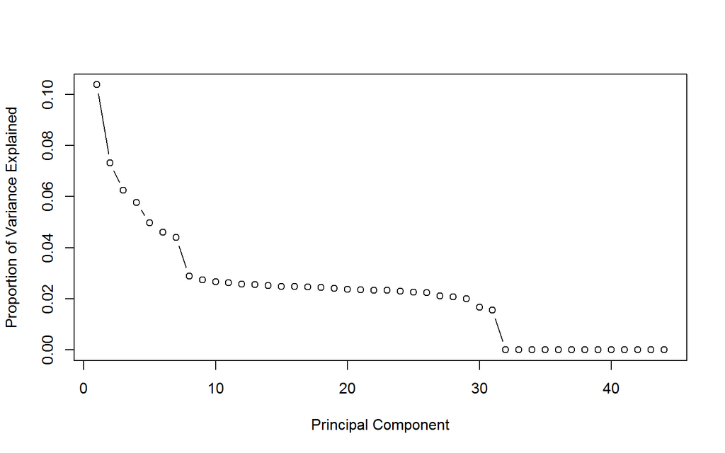

```r
plot(prop_varex, xlab = "Principal Component", ylab = "Proportion of Variance Explained", type = "b")
```

The plot above shows that ~ 30 components explains around 98.4% variance in the data set. In order words, using PCA we have reduced 44 predictors to 30 without compromising on explained variance. This is the power of PCA. Confirm by plotting a cumulative variance plot. This will give us a clear picture of number of components.

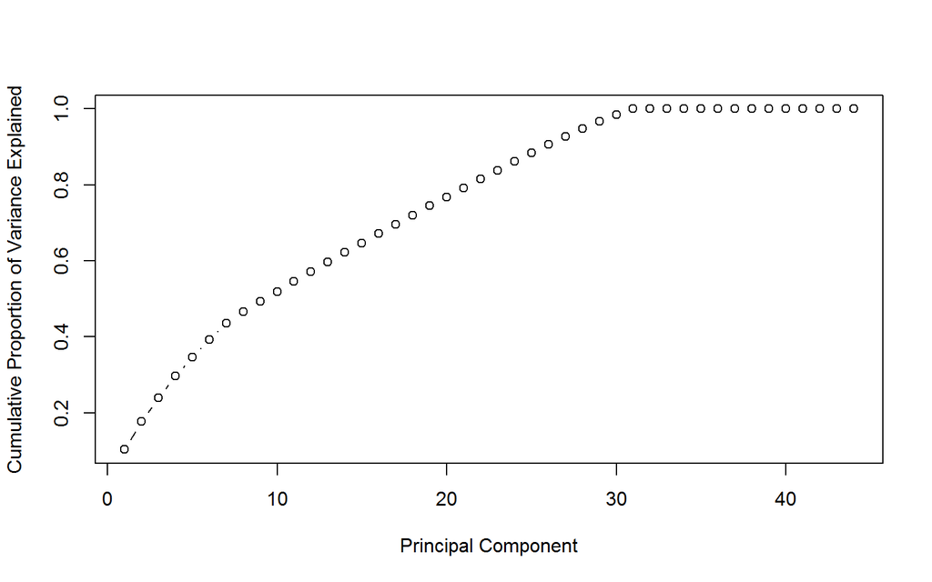

```r
#cumulative scree plot
plot(cumsum(prop_varex), xlab = "Principal Component", ylab = "Cumulative Proportion of Variance Explained", type = "b")
```

This plot shows that 30 components results in variance close to ~ 98%. Therefore, in this case, we’ll select number of components as 30 [PC1 to PC30] and proceed to the modeling stage. This completes the steps to implement PCA on train data. For modeling, we’ll use these 30 components as predictor variables and follow the normal procedures.

Continue to modeling in the Appendix https://www.analyticsvidhya.com/blog/2016/03/practical-guide-principal-component-analysis-python/

I think that was too much code for the PCA analysis. Use `FactomineR` to faster results.

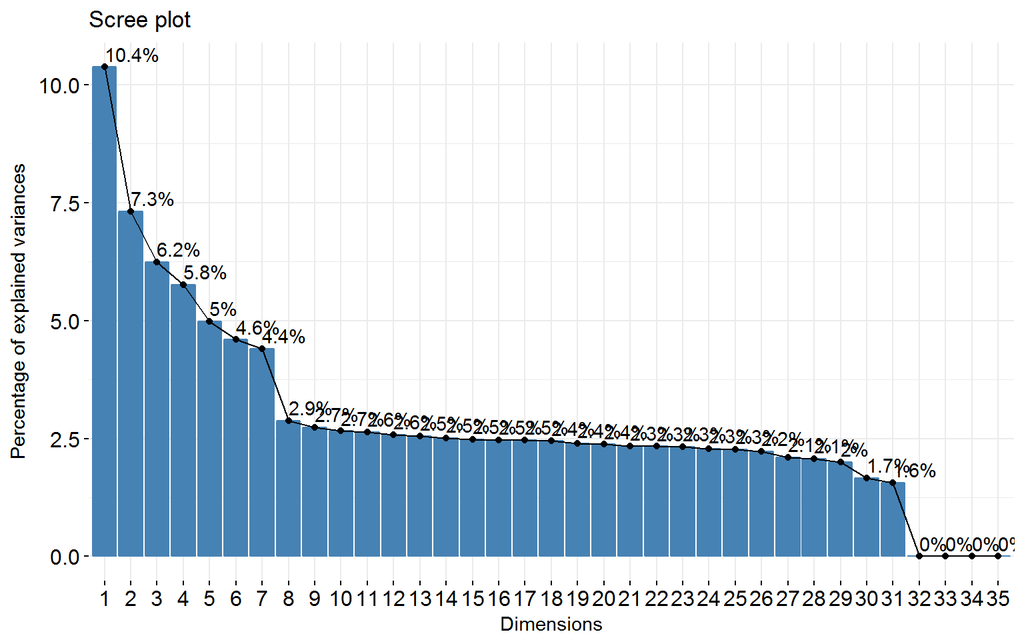

```r
results_pca <- PCA(pca.train, graph = FALSE)
fviz_eig(results_pca, addlabels = TRUE, nc=35)
```

Of course you can also to the eigenvalues that describe the variance explained by each dimension.

```r
results_pca$eig
```

```
##           eigenvalue percentage of variance
## comp 1  4.564631e+00           1.037416e+01
## comp 2  3.219279e+00           7.316543e+00
## comp 3  2.744497e+00           6.237493e+00
## comp 4  2.535883e+00           5.763369e+00
## comp 5  2.190449e+00           4.978294e+00
## comp 6  2.021640e+00           4.594636e+00
## comp 7  1.935010e+00           4.397749e+00
## comp 8  1.266311e+00           2.877979e+00
## comp 9  1.205757e+00           2.740357e+00
## comp 10 1.169495e+00           2.657943e+00
## comp 11 1.157668e+00           2.631063e+00
## comp 12 1.134279e+00           2.577906e+00
## comp 13 1.121861e+00           2.549683e+00
## comp 14 1.104976e+00           2.511309e+00
## comp 15 1.089968e+00           2.477200e+00
## comp 16 1.086434e+00           2.469167e+00
## comp 17 1.082838e+00           2.460995e+00
## comp 18 1.076252e+00           2.446028e+00
## comp 19 1.055437e+00           2.398721e+00
## comp 20 1.044325e+00           2.373467e+00
## comp 21 1.029846e+00           2.340558e+00
## comp 22 1.025624e+00           2.330965e+00
## comp 23 1.022594e+00           2.324078e+00
## comp 24 1.005662e+00           2.285594e+00
## comp 25 9.959416e-01           2.263504e+00
## comp 26 9.814766e-01           2.230629e+00
## comp 27 9.249624e-01           2.102187e+00
## comp 28 9.094469e-01           2.066925e+00
## comp 29 8.793914e-01           1.998617e+00
## comp 30 7.310976e-01           1.661585e+00
## comp 31 6.869703e-01           1.561296e+00
## comp 32 3.218893e-28           7.315665e-28
## comp 33 9.002041e-31           2.045919e-30
## comp 34 5.903224e-31           1.341642e-30
## comp 35 3.149869e-31           7.158793e-31
## comp 36 2.682619e-31           6.096861e-31
## comp 37 2.090754e-31           4.751713e-31
## comp 38 1.057692e-31           2.403846e-31
## comp 39 4.571945e-32           1.039078e-31
```

[output cut: 35 more lines]

```
## comp 30                          98.43870
## comp 31                         100.00000
## comp 32                         100.00000
## comp 33                         100.00000
## comp 34                         100.00000
## comp 35                         100.00000
## comp 36                         100.00000
## comp 37                         100.00000
## comp 38                         100.00000
## comp 39                         100.00000
## comp 40                         100.00000
## comp 41                         100.00000
## comp 42                         100.00000
## comp 43                         100.00000
## comp 44                         100.00000
```

FactoMineR does much more. See Appendix

# Factor Analysis For Mixed Data

## Introduction to FAMD

Factor Analysis For Mixed Data (FAMD) is a principal component method dedicated to explore data with both continuous and categorical variables. It can be seen roughly as a mixed between PCA and MCA. More precisely, the continuous variables are scaled to unit variance and the categorical variables are transformed into a disjunctive data table (crisp coding) and then scaled using the specific scaling of MCA. This ensures to balance the influence of both continuous and categorical variables in the analysis. It means that both variables are on a equal foot to determine the dimensions of variability. This method allows one to study the similarities between individuals taking into account mixed variables and to study the relationships between all the variables. It also provides graphical outputs such as the representation of the individuals, the correlation circle for the continuous variables and representations of the categories of the categorical variables, and also specific graphs to visualize the associations between both type of variables.

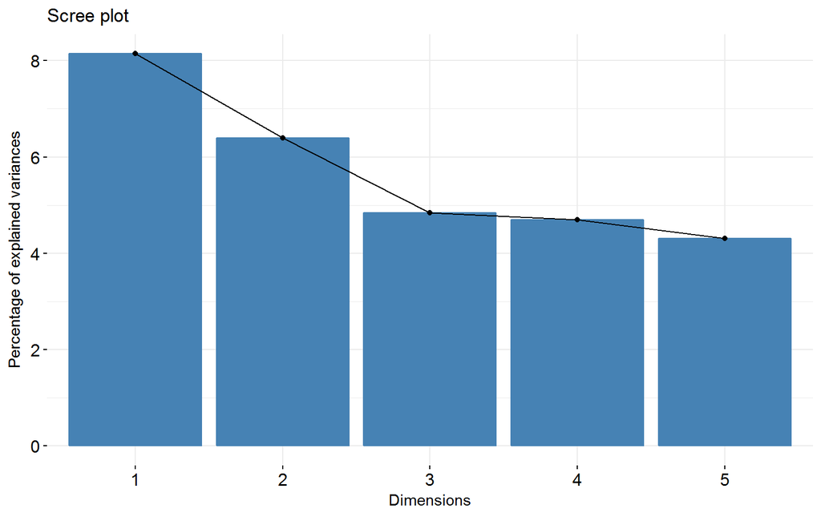

```r
result_FAMD <- FAMD(my_data, graph = FALSE)
fviz_screeplot(result_FAMD, ncp=35)
```

```r
result_FAMD$eig
```

```
##        eigenvalue percentage of variance cumulative percentage of variance
## comp 1   2.524595               8.143854                          8.143854
## comp 2   1.980815               6.389727                         14.533581
## comp 3   1.500298               4.839669                         19.373250
## comp 4   1.455155               4.694049                         24.067299
## comp 5   1.334548               4.304994                         28.372294
```

While the results are disappointing (28.3% variance explained), this is likely due to the fact there were only 9 variables to begin with. (Not exactly a high dimensional problem!) This does not invalidate the tool. If were were to use a different data set, the results are much improved as shown below. Note, it is trial an error to select the variables that provide the greatest cumulative percentage of variance. It helps to consider the plot with the most influential variables as well and the impact of variables on each dimension. You cam also create a DF (like the one below - contrib) and evaluate the dimensions with the highest values.

This is how the df below was created.

```r
data(wine)
str(wine)
```

```
## 'data.frame':    21 obs. of  31 variables:
##  $ Label                        : Factor w/ 3 levels "Saumur","Bourgueuil",..: 1 1 2 3 1 2 2 1 3 1 ...
##  $ Soil                         : Factor w/ 4 levels "Reference","Env1",..: 2 2 2 3 1 1 1 2 2 3 ...
##  $ Odor.Intensity.before.shaking: num  3.07 2.96 2.86 2.81 3.61 ...
##  $ Aroma.quality.before.shaking : num  3 2.82 2.93 2.59 3.43 ...
##  $ Fruity.before.shaking        : num  2.71 2.38 2.56 2.42 3.15 ...
##  $ Flower.before.shaking        : num  2.28 2.28 1.96 1.91 2.15 ...
##  $ Spice.before.shaking         : num  1.96 1.68 2.08 2.16 2.04 ...
##  $ Visual.intensity             : num  4.32 3.22 3.54 2.89 4.39 ...
##  $ Nuance                       : num  4 3 3.39 2.79 4.04 ...
##  $ Surface.feeling              : num  3.27 2.81 3 2.54 3.38 ...
##  $ Odor.Intensity               : num  3.41 3.37 3.25 3.16 3.54 ...
##  $ Quality.of.odour             : num  3.31 3 2.93 2.88 3.36 ...
##  $ Fruity                       : num  2.88 2.56 2.77 2.39 3.16 ...
##  $ Flower                       : num  2.32 2.44 2.19 2.08 2.23 ...
```

[output cut: 17 more lines]

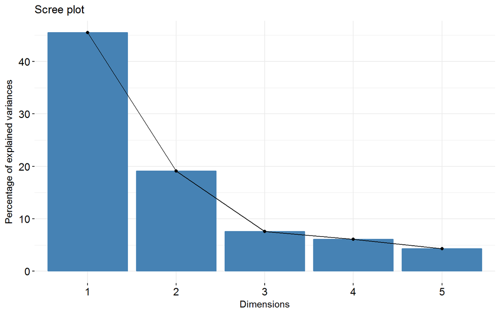

```r
result_FAMD2 <- FAMD(wine, graph = FALSE)
fviz_screeplot(result_FAMD2, ncp=10)
```

```r
result_FAMD2$eig
```

```
##        eigenvalue percentage of variance cumulative percentage of variance
## comp 1  15.466717              45.490344                          45.49034
## comp 2   6.488023              19.082421                          64.57276
## comp 3   2.578934               7.585100                          72.15786
## comp 4   2.067096               6.079693                          78.23756
## comp 5   1.455980               4.282294                          82.51985
```

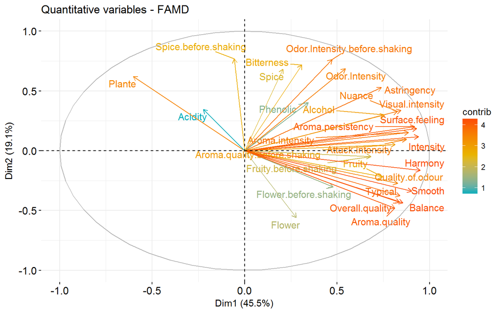

```r
fviz_famd_var(result_FAMD2, "quanti.var", repel = TRUE, col.var = "contrib", gradient.cols=c("#00AFBB", "#E7B800", "#FC4E07"))
```

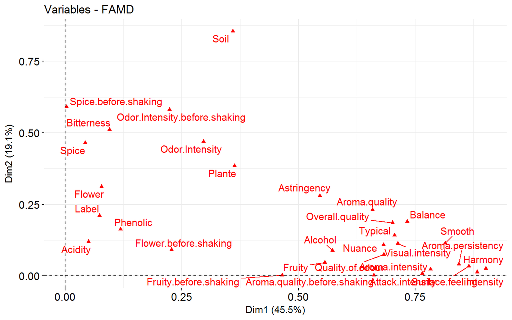

```r
fviz_famd_var(result_FAMD2, repel = TRUE)
```

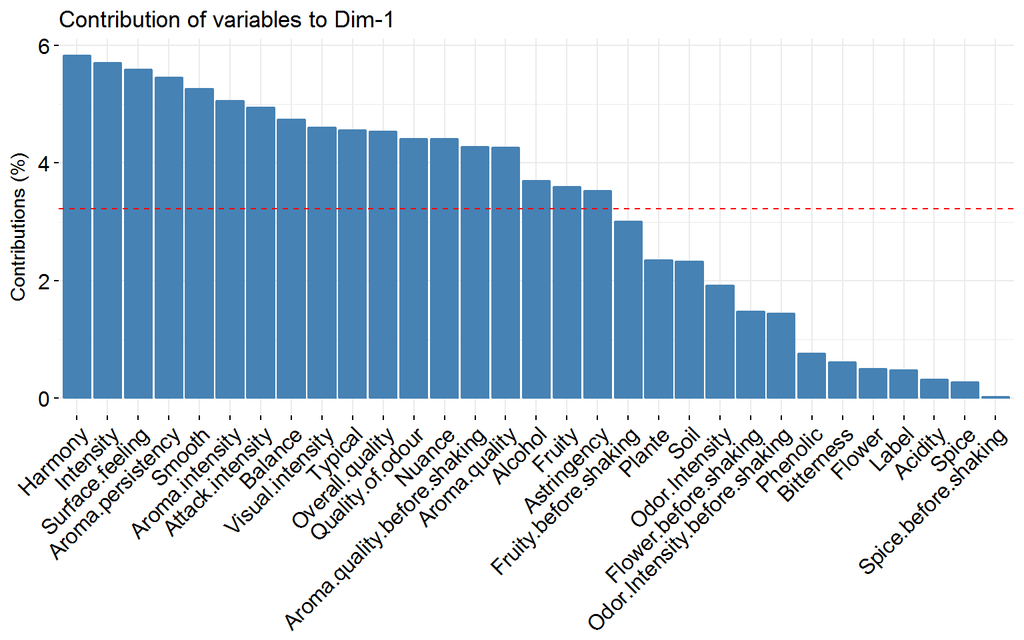

```r
fviz_contrib(result_FAMD2, "var", axes = 1)
```

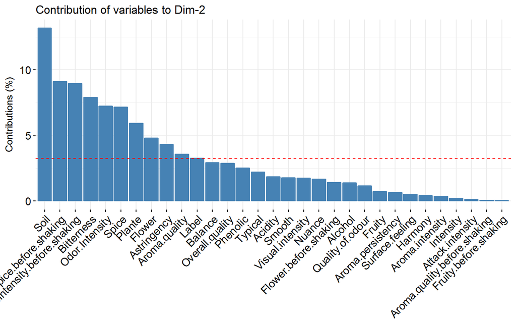

```r
fviz_contrib(result_FAMD2, "var", axes = 2)
```

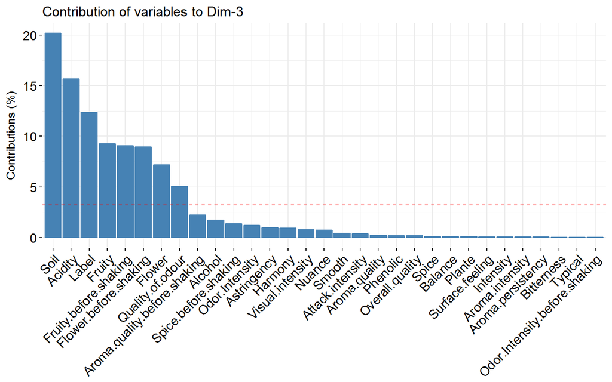

```r
fviz_contrib(result_FAMD2, "var", axes = 3)
```

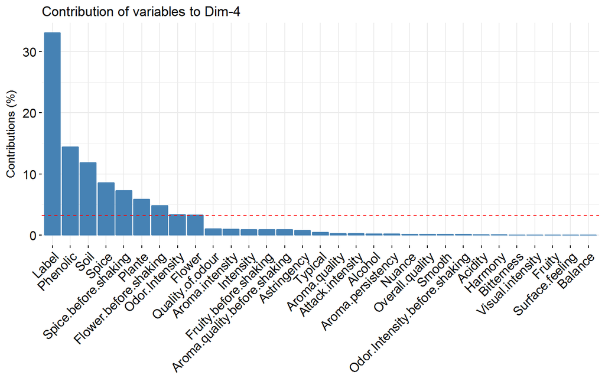

```r
fviz_contrib(result_FAMD2, "var", axes = 4)
```

```r
quanti.var <- get_famd_var(result_FAMD2, "quanti.var")
quanti.var$contrib
```

```
##                                   Dim.1      Dim.2       Dim.3
## Odor.Intensity.before.shaking 1.4442581 8.96420854  0.03646677
## Aroma.quality.before.shaking  4.2789142 0.04305414  2.23461434
## Fruity.before.shaking         3.0065664 0.03582371  9.07295301
## Flower.before.shaking         1.4737847 1.41620424  8.94766815
## Spice.before.shaking          0.0199745 9.10214361  1.36377347
## Visual.intensity              4.6090123 1.74931166  0.79549110
## Nuance                        4.4090928 1.67511875  0.72845447
## Surface.feeling               5.5925373 0.52461973  0.08910779
## Odor.Intensity                1.9190364 7.24234462  1.20744289
## Quality.of.odour              4.4165784 1.15600664  5.05738036
## Fruity                        3.6000345 0.72870130  9.26658799
## Flower                        0.5047307 4.80760152  7.18824393
## Spice                         0.2772267 7.16241162  0.12926389
## Plante                        2.3464774 5.93239816  0.11750887
## Phenolic                      0.7658296 2.51805264  0.20901041
## Aroma.intensity               5.0639740 0.35875520  0.07713809
## Aroma.persistency             5.4551799 0.63285286  0.06219337
## Aroma.quality                 4.2604725 3.55813594  0.23071799
## Attack.intensity              4.9454588 0.13787979  0.39613871
## Acidity                       0.3232790 1.84731624 15.68718257
## Astringency                   3.5282351 4.30819373  0.99418728
## Alcohol                       3.7036372 1.37714928  1.72072611
## Balance                       4.7401786 2.93153724  0.12406826
## Smooth                        5.2668235 1.77193229  0.43744057
## Bitterness                    0.6158573 7.89318173  0.04081239
## Intensity                     5.7102775 0.21321623  0.08597468
## Harmony                       5.8277438 0.40740517  0.92856960
## Overall.quality               4.5338988 2.86996960  0.19126904
## Typical                       4.5615589 2.19948282  0.03688648
##                                      Dim.4        Dim.5
## Odor.Intensity.before.shaking 1.036570e-01  1.264148715
## Aroma.quality.before.shaking  8.758749e-01  6.673160864
## Fruity.before.shaking         9.129277e-01  2.752777097
## Flower.before.shaking         4.849010e+00  3.793835543
## Spice.before.shaking          7.290504e+00  5.064338896
## Visual.intensity              1.764957e-02  0.817205495
## Nuance                        1.359006e-01  0.631594556
## Surface.feeling               3.078473e-04  0.687508872
## Odor.Intensity                3.346404e+00  0.025686660
## Quality.of.odour              1.030670e+00  0.189596705
## Fruity                        5.893980e-03  3.465261855
## Flower                        3.307603e+00 15.154681392
## Spice                         8.592423e+00  1.552617127
## Plante                        5.855886e+00  0.101979266
## Phenolic                      1.439720e+01  0.033850992
## Aroma.intensity               9.413492e-01  3.665621490
## Aroma.persistency             2.182450e-01  3.668175562
## Aroma.quality                 2.437075e-01  0.109694036
## Attack.intensity              2.368782e-01  4.280227052
## Acidity                       6.279658e-02 18.961196489
## Astringency                   7.508433e-01  0.469261126
## Alcohol                       2.221745e-01  0.289032996
## Balance                       3.098762e-05  0.024737799
## Smooth                        1.174289e-01  0.008009685
## Bitterness                    3.216653e-02  3.419837944
## Intensity                     9.149856e-01  2.619681210
## Harmony                       4.429150e-02  0.036117231
## Overall.quality               1.200342e-01  1.593943787
## Typical                       4.761355e-01  0.006709979
```

```r
contrib <- as.data.frame(quanti.var$contrib)
```

```r
df <- wine[, c(1, 2, 16, 22, 25, 26, 29, 28, 29, 30, 31)]
result_FAMD3 <- FAMD(df, graph = FALSE)
result_FAMD3$eig
```

```
##        eigenvalue percentage of variance cumulative percentage of variance
## comp 1  7.6142015              54.387153                          54.38715
## comp 2  1.8822832              13.444880                          67.83203
## comp 3  1.6225676              11.589769                          79.42180
## comp 4  1.1872524               8.480374                          87.90218
## comp 5  0.6600101               4.714358                          92.61653
```

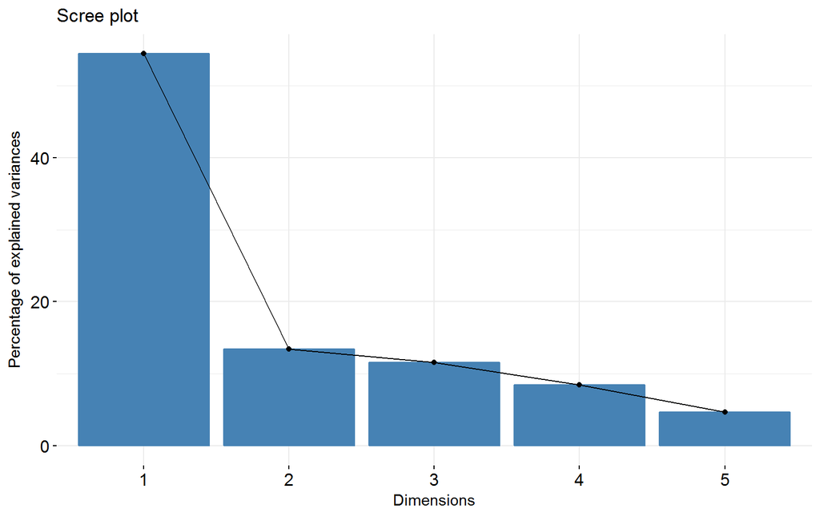

```r
fviz_screeplot(result_FAMD3, ncp=10)
```

# Principal Component Analysis of Mixed Data - PCAmixdata

Performs principal component analysis of a set of individuals (observations) described by a mixture of qualitative and quantitative variables. PCAmix includes ordinary principal component analysis (PCA) and multiple correspondence analysis (MCA) as special cases.

```r
#PCAMIX:
X.quanti <- splitmix(wine)$X.quanti
X.quali <- splitmix(wine)$X.quali
pca<-PCAmix(X.quanti[,1:27],X.quali,ndim=4)
pca<-PCAmix(X.quanti[,1:27],X.quali,ndim=4,graph=FALSE)
pca$eig
```

```
##         Eigenvalue  Proportion Cumulative
## dim 1  14.12902429 44.15320091   44.15320
## dim 2   6.11105247 19.09703896   63.25024
## dim 3   2.57327334  8.04147918   71.29172
## dim 4   2.05569005  6.42403142   77.71575
## dim 5   1.43368245  4.48025766   82.19601
## dim 6   1.17497297  3.67179052   85.86780
## dim 7   0.95790392  2.99344975   88.86125
## dim 8   0.83822418  2.61945055   91.48070
## dim 9   0.58804867  1.83765210   93.31835
## dim 10  0.55460417  1.73313802   95.05149
## dim 11  0.42551449  1.32973278   96.38122
## dim 12  0.39132634  1.22289482   97.60412
## dim 13  0.24992995  0.78103110   98.38515
## dim 14  0.15837938  0.49493555   98.88008
## dim 15  0.11421382  0.35691817   99.23700
## dim 16  0.07888685  0.24652141   99.48352
## dim 17  0.06783051  0.21197034   99.69549
## dim 18  0.04394092  0.13731539   99.83281
## dim 19  0.03908925  0.12215391   99.95496
## dim 20  0.01441199  0.04503746  100.00000
```

# LDA

============

# Appendix

## Model using pCA Results

https://www.analyticsvidhya.com/blog/2016/03/practical-guide-principal-component-analysis-python/

## Do More with FactomineR

fviz_contrib(results_pca, choice = “var”, axes = 1:3, top = 10) - See book page 26

## Introduction to teh Data

gironde is a list of 4 datasets characterizing conditions of life of 542 cities in Gironde. The four datasets correspond to four thematics relative to conditions of life. Each dataset contains a different number of variables (quantitative and/or qualitative). The first three datasets come from the 2009 population census realized in Gironde by INSEE (Institut National de la Statistique et des Etudes Economiques). The fourth come from an IGN (Institut National de l’Information Geographique et forestiere) database.

1. **gironde$employment**: This data frame contains the description of 542 cities by 9 quantitative variables. These variables are related to employment conditions like, for instance, the average income (income), the percentage of farmers (farmer).
2. **gironde$housing**: This data frame contains the description of 542 cities by 5 variables (2 qualitative variables and 3 quantitative variables). These variables are related to housing conditions like, for instance, the population density (density), the percentage of counsel housing within the cities (council).
3. **gironde$services**: This data frame contains the description of 542 cities by 9 qualitative variables. These variables are related to the number of services within the cities, like, for instance, the number of bakeries (baker) or the number of post office (postoffice).
4. **gironde$environment**: This data frame contains the description of 542 cities by 4 quantitative variables. These variables are related to the natural environment of the cities, like, for instance the percentage of agricultural land (agricul) or the percentage of buildings (building).

## PCAmix

The datatable **housing** is used.

```r
library(PCAmixdata)
data(gironde)
head(gironde$housing)
```

```
##                    density primaryres   houses owners council
## ABZAC               131.70      88.77  inf 90%  64.23  sup 5%
## AILLAS               21.21      87.52  sup 90%  77.12  inf 5%
## AMBARES-ET-LAGRAVE  531.99      94.90  inf 90%  65.74  sup 5%
## AMBES               101.21      93.79  sup 90%  66.54  sup 5%
## ANDERNOS-LES-BAINS  551.87      62.14  inf 90%  71.54  inf 5%
## ANGLADE              63.82      81.02  sup 90%  80.54  inf 5%
```

The **PCAmix** function is applied to this datatable.

```r
split <- splitmix(gironde$housing)
X1 <- split$X.quanti
X2 <- split$X.quali
res.pcamix <- PCAmix(X.quanti=X1, X.quali=X2, rename.level=TRUE, graph=FALSE)
```

The object **res.pcamix** contains many numerical results summarized in the S3 **print** method.

```r
res.pcamix
```

```
##
## Call:
## PCAmix(X.quanti = X1, X.quali = X2, rename.level = TRUE, graph = FALSE)
##
## Method = Principal Component of mixed data (PCAmix)
##
##
##      name
## [1,] "$eig"
## [2,] "$ind"
## [3,] "$quanti"
## [4,] "$levels"
## [5,] "$quali"
## [6,] "$sqload"
## [7,] "$coef"
##      description
## [1,] "eigenvalues of the principal components (PC) "
## [2,] "results for the individuals (coord,contrib,cos2)"
## [3,] "results for the quantitative variables (coord,contrib,cos2)"
## [4,] "results for the levels of the qualitative variables (coord,contrib,cos2)"
## [5,] "results for the qualitative variables (coord,contrib,cos2)"
## [6,] "squared loadings"
## [7,] "coef of the linear combinations defining the PC"
```

The variance of the principal components is obtained.

```r
res.pcamix$eig
```

```
##       Eigenvalue Proportion Cumulative
## dim 1  2.5268771  50.537541   50.53754
## dim 2  1.0692777  21.385553   71.92309
## dim 3  0.6303253  12.606505   84.52960
## dim 4  0.4230216   8.460432   92.99003
## dim 5  0.3504984   7.009968  100.00000
```

### Graphical outputs

Here are some graphical outputs.

[figure not shown]

```r
par(mfrow=c(2,2))
plot(res.pcamix,choice="ind",coloring.ind=X2$houses,label=FALSE, posleg="bottomright", main="Observations")
plot(res.pcamix,choice="levels",xlim=c(-1.5,2.5), main="Levels")
plot(res.pcamix,choice="cor",main="Numerical variables")
plot(res.pcamix,choice="sqload",coloring.var=T, leg=TRUE, posleg="topright", main="All variables")
```

It is also possible to select some observations to plot.

```r
sort(res.pcamix$ind$coord[,2])[1:10]
```

```
##  VENDAYS-MONTALIVET             CARCANS             LACANAU
##           -6.171971           -6.087304           -6.070451
##      SOULAC-SUR-MER GRAYAN-ET-L'HOPITAL     LEGE-CAP-FERRET
##           -5.802359           -5.791642           -5.596315
##      VERDON-SUR-MER             HOURTIN            ARCACHON
##           -5.008545           -4.493259           -4.013374
##               PORGE
##           -3.751233
```

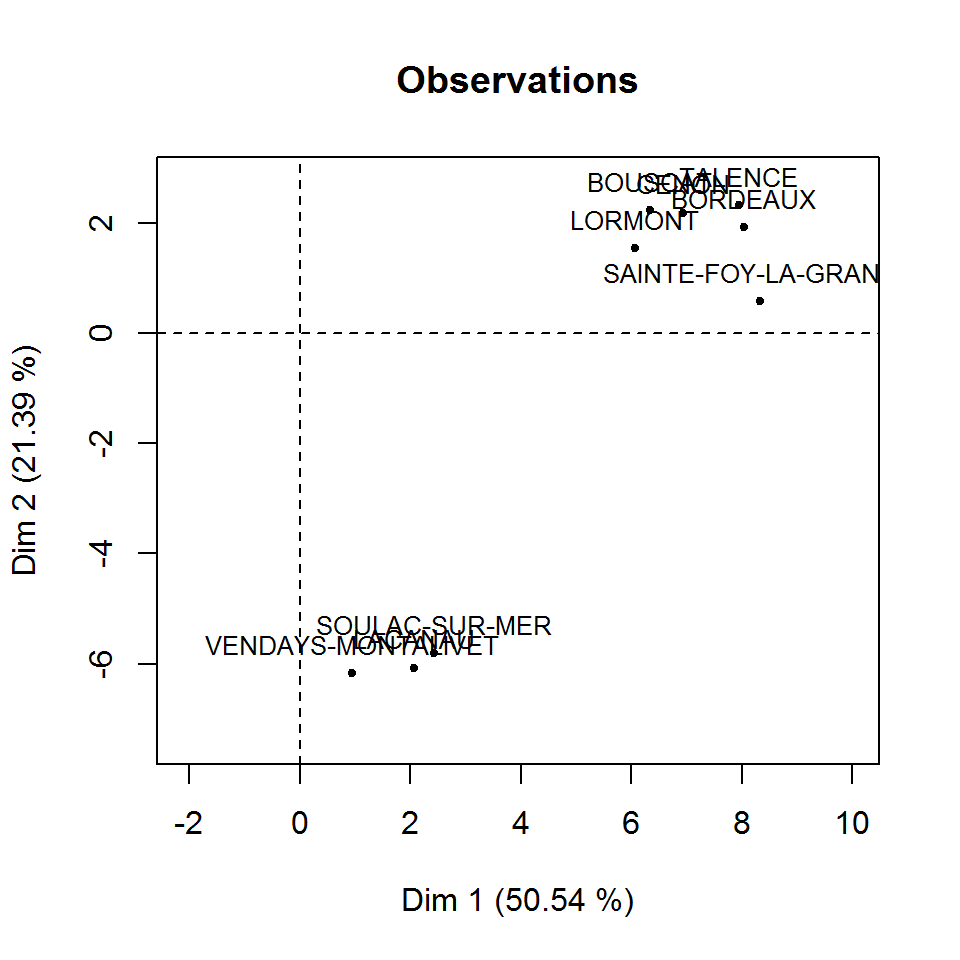

```r
plot(res.pcamix,choice="ind",lim.contrib.plot = 2, posleg="bottomright", main="Observations",cex=0.8)
```

### Prediction and plot of new observations.

We select randomly 100 observations to build a test sample. The remaining observations are in a train sample used to perform **PCAmix**.

```r
set.seed(10)
test <- sample(1:nrow(gironde$housing),100)
train.pcamix <- PCAmix(X1[-test,],X2[-test,],ndim=2,graph=FALSE)
```

The scores of the 100 observations are obtained with the S3 method **predict.PCAmix**.

```r
pred <- predict.PCAmix(train.pcamix,X1[test,],X2[test,])
head(pred)
```

```
##                                dim1        dim2
## MAZION                   -0.4120140  0.03905247
## FLAUJAGUES               -0.6881160 -0.33163728
## LATRESNE                  0.7447583  0.65305517
## SAINT-CHRISTOLY-DE-BLAYE -0.7006372 -0.33216807
## BERSON                   -1.1426625  0.33607088
## CHAMADELLE               -1.3781919  0.24609791
```

It is then possible to plot these observation as supplementary on the principal component map.

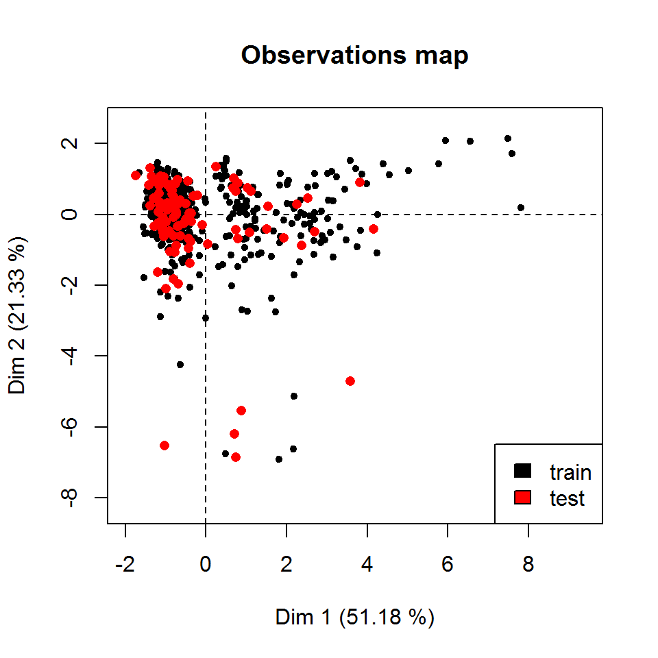

```r
plot(train.pcamix,axes=c(1,2),label=FALSE,main="Observations map")
points(pred,col=2,pch=16)
legend("bottomright",legend = c("train","test"),fill=1:2,col=1:2)
```

## PCArot

We apply here the function **PCArot** to perform varimax-type rotation to the result of **PCAmix** applied to the datatable **housing**. The 10 first observations are removed to illustrate later the prediction of new observations.

```r
data(gironde)
#Create the datatable housing without the ten first observations
train <- gironde$housing[-c(1:10), ]
#Split the datatable
split <- splitmix(train)
X1 <- split$X.quanti
X2 <- split$X.quali
res.pcamix <- PCAmix(X.quanti=X1, X.quali=X2,rename.level=TRUE, graph=FALSE)
```

In order to choose the number of dimension to rotate, we look at the inertia of the principal components again.

```r
res.pcamix$eig
```

```
##       Eigenvalue Proportion Cumulative
## dim 1  2.5189342  50.378685   50.37868
## dim 2  1.0781913  21.563825   71.94251
## dim 3  0.6290897  12.581794   84.52430
## dim 4  0.4269180   8.538361   93.06267
## dim 5  0.3468667   6.937335  100.00000
```

We decide to rotate 3 principal components that summarize 84% of the inertia.

```r
res.pcarot <- PCArot(res.pcamix,dim=3,graph=FALSE)
res.pcarot$eig #variance of the rotated PCs
```

```
##          Variance Proportion
## dim1.rot 1.919546   38.39092
## dim2.rot 1.057868   21.15737
## dim3.rot 1.248801   24.97601
```

```r
sum(res.pcarot$eig[,2]) #unchanged explained inertia
```

```
## [1] 84.5243
```

The object **res.pcarot** contains many numerical results summarized in the S3 **print** method.

```r
res.pcarot
```

```
##
## Call:
## PCArot(obj = res.pcamix, dim = 3, graph = FALSE)
##
## Method = rotation after Principal Component of mixed data (PCAmix)
## number of iterations:  4
##
##       name
##  [1,] "$eig"
##  [2,] "$ind"
##  [3,] "$quanti"
##  [4,] "$levels"
##  [5,] "$quali"
##  [6,] "$sqload"
##  [7,] "$coef"
##  [8,] "$theta"
##  [9,] "$T"
##       description
##  [1,] "variances of the 'ndim' first dimensions after rotation"
##  [2,] "results for the individuals after rotation (coord)"
##  [3,] "results for the quantitative variables (coord) after rotation"
##  [4,] "results for the levels of the qualitative variables (coord) after rotation"
##  [5,] "results for the qualitative variables (coord) after rotation "
##  [6,] "squared loadings after rotation"
##  [7,] "coef of the linear combinations defining the rotated PC"
##  [8,] "angle of rotation if 'dim'=2"
##  [9,] "matrix of rotation if 'dim'=2"
```

We can look at the squared loadings before and after rotation.

```r
round(res.pcamix$sqload[,1:3],digit=2)
```

```
##            dim1 dim2 dim3
## density    0.49 0.07 0.39
## primaryres 0.00 0.94 0.02
## owners     0.73 0.02 0.00
## houses     0.68 0.03 0.03
## council    0.61 0.01 0.18
```

```r
round(res.pcarot$sqload,digit=2)
```

```
##            dim1.rot dim2.rot dim3.rot
## density        0.04     0.01     0.90
## primaryres     0.00     0.96     0.01
## owners         0.48     0.03     0.25
## houses         0.63     0.03     0.08
## council        0.76     0.03     0.01
```

### Graphical outputs

It is also possible to plot all the standard maps of **PCAmix** before and after rotation. For instance we can plot the observations and variables before and after rotation in the dimensions 1 and 3.

[figure not shown]

```r
par(mfrow=c(2,2))
plot(res.pcamix,choice="ind",label=FALSE,axes=c(1,3), main="Observations before rotation")
plot(res.pcarot,choice="ind",label=FALSE,axes=c(1,3), main="Observations after rotation")
plot(res.pcamix,choice="sqload", coloring.var=TRUE, leg=TRUE,axes=c(1,3), posleg="topleft", main="Variables before rotation", xlim=c(0,1), ylim=c(0,1))
plot(res.pcarot,choice="sqload", coloring.var=TRUE, leg=TRUE,axes=c(1,3),
     posleg="topright", main="Variables after rotation", xlim=c(0,1), ylim=c(0,1))
```

It also possible to plot the numerical variables (on the correlation circle) or the levels of the categorical variables.

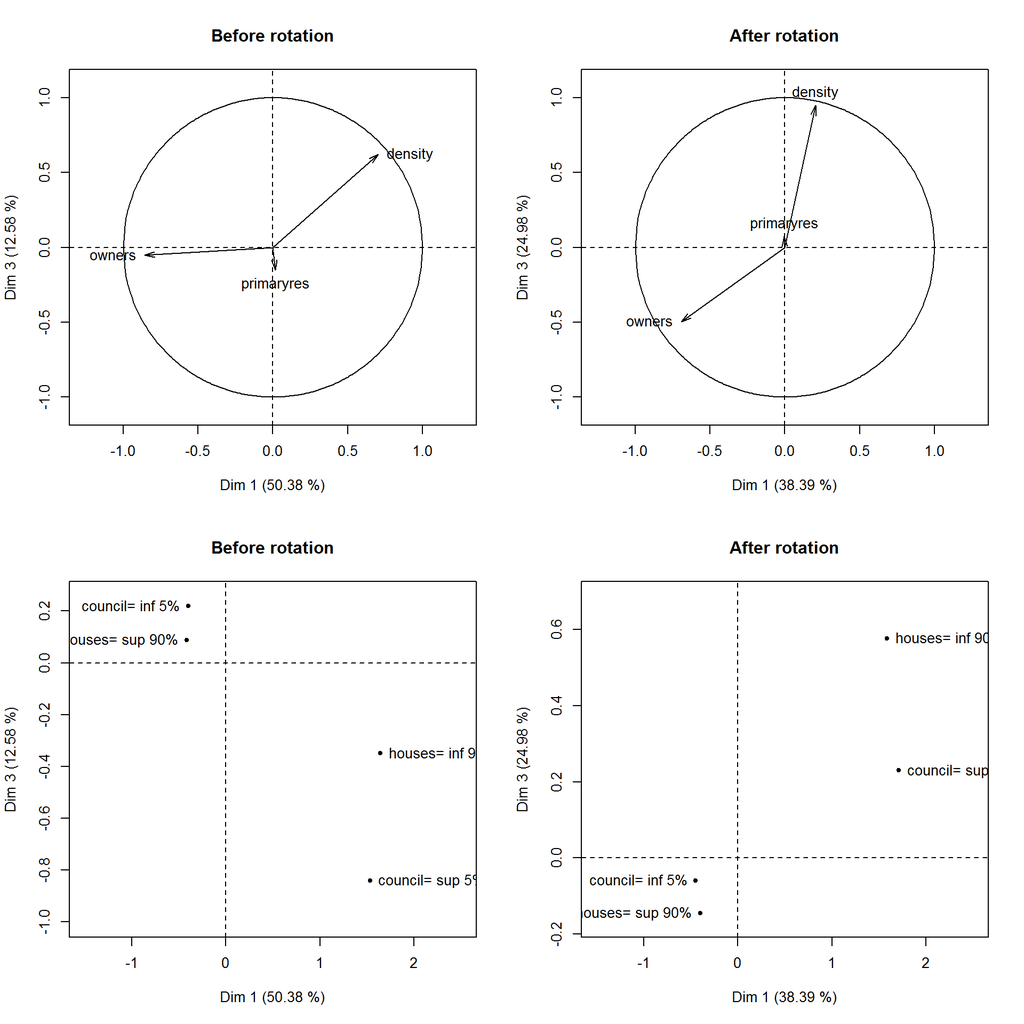

```r
par(mfrow=c(2,2))
plot(res.pcamix,choice="cor", coloring.var=TRUE, leg=TRUE,axes=c(1,3), posleg="topright", main="Before rotation")
plot(res.pcarot,choice="cor", coloring.var=TRUE, leg=TRUE,axes=c(1,3), posleg="topright", main="After rotation")
plot(res.pcamix,choice="levels",  leg=TRUE,axes=c(1,3), posleg="topright", main="Before rotation",xlim=c(-1.5,2.5))
plot(res.pcarot,choice="levels", leg=TRUE,axes=c(1,3), posleg="topright", main="After rotation",xlim=c(-1.5,2.5))
```

### Prediction and plot of new observations.

It is possible, exactly as in **PCAmix**, to predict the scores of new observations on the principal components after rotation.

```r
test <- gironde$housing[1:10, ]
splitnew <- splitmix(test)
X1new <- splitnew$X.quanti
X2new<-splitnew$X.quali
pred.rot <- predict(object=res.pcarot, X.quanti=X1new, X.quali=X2new)
pred.rot
```

```
##                      dim1.rot   dim2.rot    dim3.rot
## ABZAC               3.2685436  0.3494533 -0.85177749
## AILLAS             -0.7235629  0.1200285 -0.22254455
## AMBARES-ET-LAGRAVE  2.8852451  0.9823515 -0.03451571
## AMBES               1.7220716  1.1590890 -0.78227835
## ANDERNOS-LES-BAINS  0.3423361 -2.6886415  0.90574890
## ANGLADE            -0.9131248 -0.4514258 -0.20108349
## ARBANATS           -0.6653760  0.4217893  0.13105217
## ARBIS              -0.7668742  0.3099338 -0.23304721
## ARCACHON            1.8825083 -4.4533014  2.36935740
## ARCINS             -0.6896492  0.2060403 -0.09049882
```

An of course these new observations can be plot as supplementary observations on the principal component map of the observations after rotation.

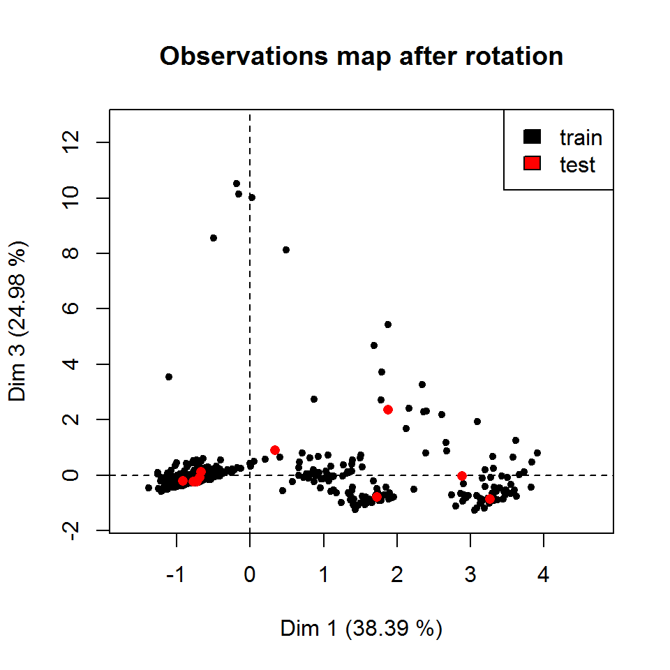

```r
plot(res.pcarot,axes=c(1,3),label=FALSE,main="Observations map after rotation")
points(pred.rot[,c(1,3)],col=2,pch=16)
legend("topright",legend = c("train","test"),fill=1:2,col=1:2)
```

# MFAmix

We use here the 4 mixed datatables available in the dataset **gironde**. This dataset is a list of 4 datatables (one datatable by group).

```r
library(PCAmixdata)
data(gironde)
names(gironde)
```

```
## [1] "employment"  "housing"     "services"    "environment"
```

Then we apply the function **MFAmix** to the four datatables concatenated in a single datatable.

```r
#Concatenation of the 4 datatables
dat <- cbind(gironde$employment,gironde$housing,gironde$services,gironde$environment)
index <- c(rep(1,9),rep(2,5),rep(3,9),rep(4,4))
names <- c("employment","housing","services","environment")
res.mfamix<-MFAmix(data=dat,groups=index, name.groups=names,ndim=3,rename.level=TRUE,graph=FALSE)
```

The object **res.mfamix** contains many numerical results summarized in the S3 **print** method.

```r
res.mfamix
```

```
## **Results of the Multiple Factor Analysis for mixed data (MFAmix)**
## The analysis was performed on 542 individuals, described by 27 variables
## *Results are available in the following objects :
##
##    name
## 1  "$eig"
## 2  "$eig.separate"
## 3  "$separate.analyses"
## 4  "$groups"
## 5  "$partial.axes"
## 6  "$ind"
## 7  "$ind.partial"
## 8  "$quanti"
## 9  "$levels"
## 10 "$quali"
## 11 "$sqload"
## 12 "$global.pca"
##    description
## 1  "eigenvalues"
## 2  "eigenvalues of the separate analyses"
## 3  "separate analyses for each group of variables"
## 4  "results for all the groups"
## 5  "results for the partial axes"
## 6  "results for the individuals"
## 7  "results for the partial individuals"
## 8  "results for the quantitative variables"
## 9  "results for the levels of the qualitative variables"
## 10 "results for the qualitative variables"
## 11 "squared loadings"
## 12 "results for the global PCA"
```

### Graphical outputs

The graphical outputs of **MFAmix** are quite similar to those of **PCAmix** with some specifity introduced by the knowedge of groups of variables.

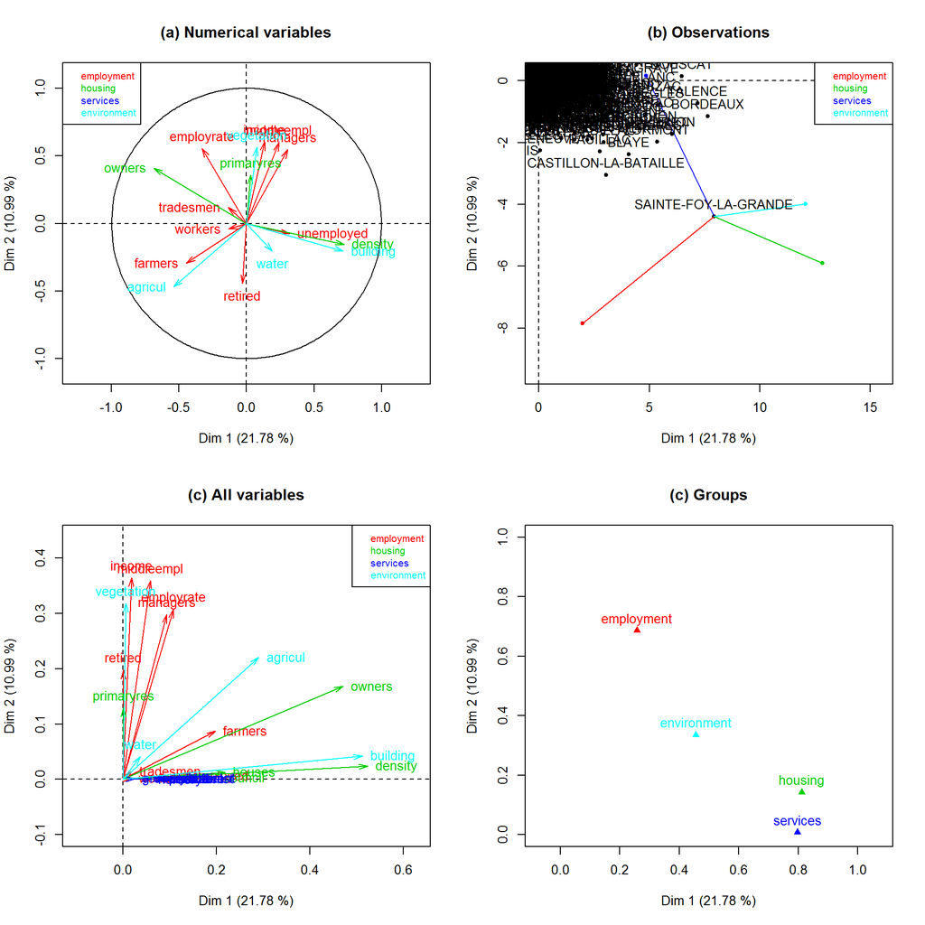

```r
par(mfrow=c(2,2))
plot(res.mfamix, choice="cor",coloring.var="groups",leg=TRUE, main="(a) Numerical variables")
plot(res.mfamix,choice="ind", partial=c("SAINTE-FOY-LA-GRANDE"), label=TRUE, posleg="topright", main="(b) Observations")
plot(res.mfamix,choice="sqload",coloring.var="groups", posleg="topright",main="(c) All variables")
plot(res.mfamix, choice="groups", coloring.var="groups", main="(c) Groups")
```

Because the correlation circle can be difficult to read with the superposition of the names of some variables, it can be useful to look at the numerical values the most correlated (in absloute value) to the 2 first principal components of **PCAmix**.

```r
coord.var <- res.mfamix$quanti$coord[,1:2]
subset(coord.var,abs(coord.var[,1])>0.5,1)
```

```
##                dim1
## density   0.7237913
## owners   -0.6863817
## building  0.7161893
## agricul  -0.5390967
```

```r
subset(coord.var,abs(coord.var[,2 ])>0.5,2)
```

```
##                 dim2
## managers   0.5463422
## middleempl 0.5992579
## employrate 0.5545209
## income     0.6038040
## vegetation 0.5642491
```

In order to have details on the way the variables of the group **services** (in blue on the map of all the variables) interpret the first principal component, we look at the map the levels of the categorical variables;

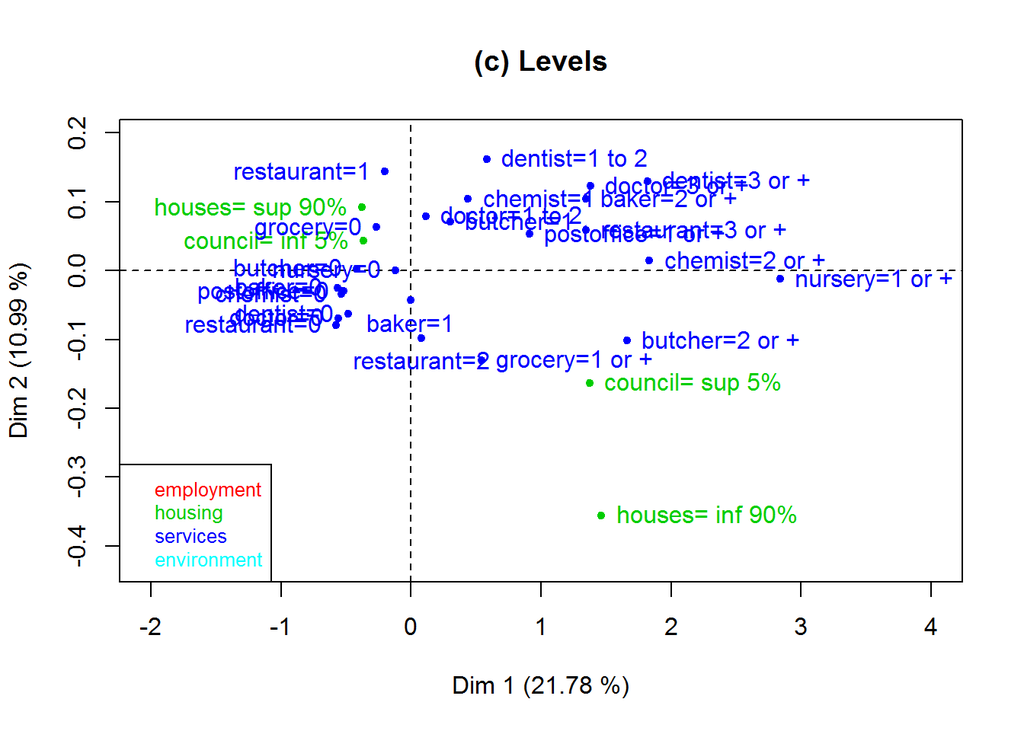

```r
plot(res.mfamix, choice="levels", coloring.var="groups", posleg="bottomleft", main="(c) Levels",xlim=c(-2,4))
```

Marie Chavent